# projet_tnd_markdown

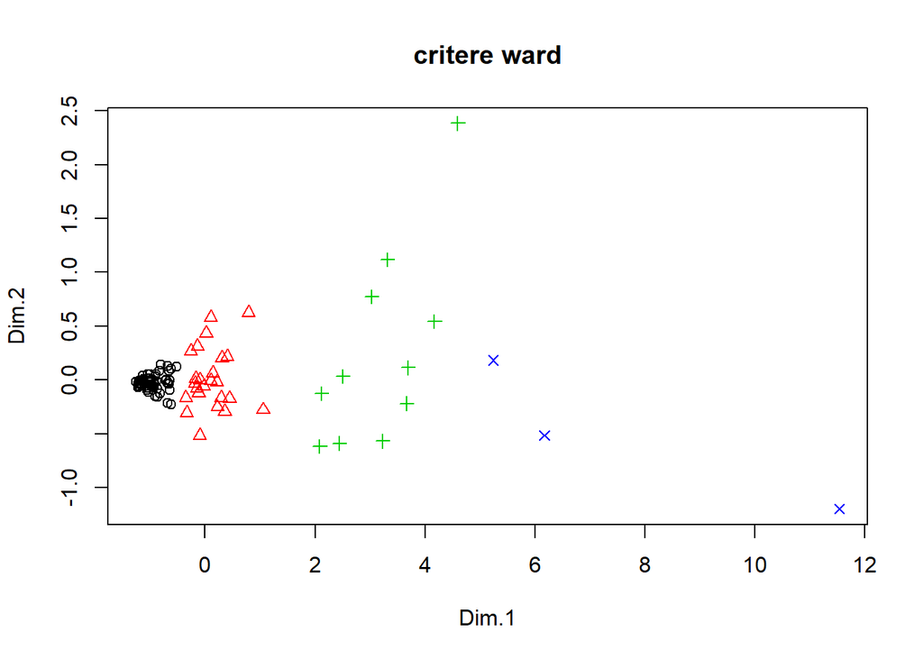

```r
plot(pca$ind$coord,col = my_classe_4,pch = my_classe_4,main = "critere ward")
```

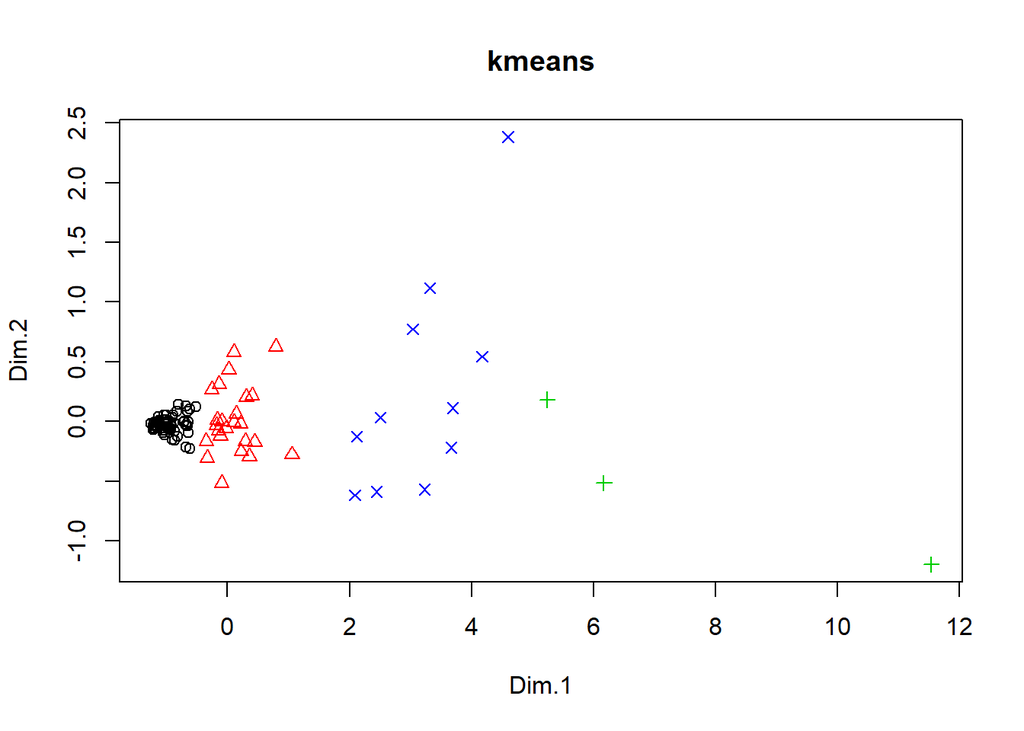

```r
plot(pca$ind$coord,col = kmean_res$cluster,pch = kmean_res$cluster,main = "kmeans")
```

### 5) Que peut-on déduire de l’analyse des résultats des trois parties ?

#Partie 1 : nous avons eu une vue global sur les chiffres, cela nous a permis de voir que le nombre d’hospitalisation et de gueris et beaucoup plus importante que les deces et reanimation ainsi que la repartition de ces chiffres en france grace aux cartes

#Partie 2 : nous avons vu qu’il y’avais une forte une correlation entre toute les variables et c’est plutot logiques car tout est lié et donc tout est une consequence d’une des autres variables, il ya des relations linéaire entre les 4 variables, cela nous a egalement permis de voir quelle variable permet une meilleure prediction du nombre de deces en l’occurence (hospitalisation)

#Partie 3 : dans cette partie nous avons etudié la similaritée des departement, cela nous a permis de créer des cleusteurs permettant la visualisations des departements ayant la meme dynamique de propagation, on ramarque d’ailleurs que <paris 76> est toujours isolée car c’est une grande ville et que les chiffres sont particuliés

#Au final : Paris a dans les 3 parties été isolée (fiabilité des résultats faible) il faudrait donc la traiter à part, on peut egalement dire que grace a l’etude on peut prevoir une strategie pour faire face au covid-19 grace au differentes analyses.

# Bonus

### 1) chargement du jeu de donnée

```r
fatality = read.csv2("fatality.csv", sep=",",dec=".")
```

### 2) classification des observations en 3 groupe

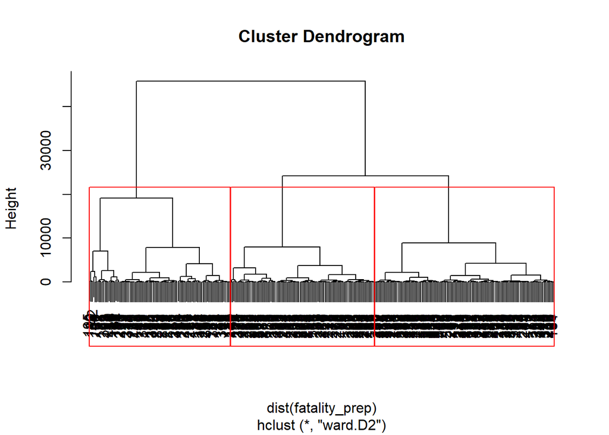

```r
fatality_prep = fatality[,c(4,5,6,9,10,11)]
#on considere uniquement les varibles quantitatives demandées

fatality_prep_hclust <- hclust(dist(fatality_prep), method = "ward.D2")
plot(fatality_prep_hclust)
rect.hclust(fatality_prep_hclust, k=3) # afin de partitionner
```

K-means

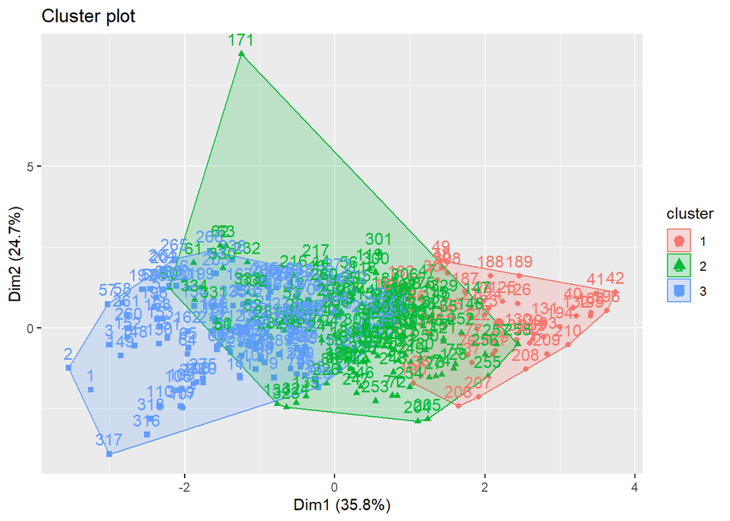

```r
kmeans_fat = kmeans(fatality_prep,centers = 3,nstart = 20)

fat_scaled= scale (fatality_prep ,center = T,scale = T)
fviz_cluster(kmeans_fat, data = fat_scaled )
```